# Drivers of readmission of diabetes patients

## 3. Exploratory Data Analysis

```r
## --------------------------------------------------- ##
## Exploratory Data Analysis
## --------------------------------------------------- ##

# This function brings a complete description of the dataset
# for both categorical and numerical variables
skimr::skim(tbl %>% dplyr::select(-readmitted))
```

Data summary

| Name | tbl %>% dplyr::select(-re… |
| --- | --- |
| Number of rows | 57642 |
| Number of columns | 25 |
| _______________________ |  |
| Column type frequency: |  |
| factor | 15 |
| numeric | 10 |
| ________________________ |  |
| Group variables | None |

**Variable type: factor**

| skim_variable | n_missing | complete_rate | ordered | n_unique | top_counts |
| --- | --- | --- | --- | --- | --- |
| race | 0 | 1 | FALSE | 5 | Cau: 43850, Afr: 11254, His: 1146, Oth: 971 |
| gender | 0 | 1 | FALSE | 2 | Fem: 30828, Mal: 26814 |
| age | 0 | 1 | FALSE | 10 | [70: 14328, [60: 13019, [50: 10276, [80: 9181 |
| admission_type_id | 0 | 1 | FALSE | 4 | Eme: 32910, Ele: 12683, Urg: 11731, Oth: 318 |
| discharge_disposition_id | 0 | 1 | FALSE | 3 | Dis: 57284, Adm: 340, Not: 18 |
| admission_source_id | 0 | 1 | FALSE | 4 | Eme: 33981, Ref: 19381, Tra: 4119, Oth: 161 |
| A1Cresult | 0 | 1 | FALSE | 4 | Non: 46764, >8: 5047, Nor: 3393, >7: 2438 |
| metformin | 0 | 1 | FALSE | 4 | No: 45238, Ste: 11328, Up: 706, Dow: 370 |
| glipizide | 0 | 1 | FALSE | 4 | No: 50221, Ste: 6619, Up: 485, Dow: 317 |
| glyburide | 0 | 1 | FALSE | 4 | No: 51664, Ste: 5196, Up: 484, Dow: 298 |
| pioglitazone | 0 | 1 | FALSE | 4 | No: 53188, Ste: 4228, Up: 160, Dow: 66 |
| rosiglitazone | 0 | 1 | FALSE | 4 | No: 53860, Ste: 3612, Up: 115, Dow: 55 |
| insulin | 0 | 1 | FALSE | 4 | No: 26505, Ste: 18419, Dow: 6648, Up: 6070 |
| change | 0 | 1 | FALSE | 2 | No: 30560, Ch: 27082 |
| diabetesMed | 0 | 1 | FALSE | 2 | Yes: 44617, No: 13025 |

**Variable type: numeric**

| skim_variable | n_missing | complete_rate | mean | sd | p0 | p25 | p50 | p75 | p100 | hist |
| --- | --- | --- | --- | --- | --- | --- | --- | --- | --- | --- |
| time_in_hospital | 0 | 1 | 4.72 | 3.16 | 1 | 2 | 4 | 6 | 14 | ▇▆▂▂▁ |
| num_lab_procedures | 0 | 1 | 44.29 | 19.65 | 1 | 33 | 45 | 58 | 132 | ▃▇▅▁▁ |
| num_procedures | 0 | 1 | 1.48 | 1.78 | 0 | 0 | 1 | 2 | 6 | ▇▂▁▁▁ |
| num_medications | 0 | 1 | 16.30 | 8.59 | 1 | 10 | 15 | 21 | 81 | ▇▅▁▁▁ |
| number_outpatient | 0 | 1 | 0.29 | 1.09 | 0 | 0 | 0 | 0 | 40 | ▇▁▁▁▁ |
| number_emergency | 0 | 1 | 0.13 | 0.67 | 0 | 0 | 0 | 0 | 63 | ▇▁▁▁▁ |
| number_inpatient | 0 | 1 | 0.32 | 0.82 | 0 | 0 | 0 | 0 | 15 | ▇▁▁▁▁ |
| number_diagnoses | 0 | 1 | 7.41 | 1.97 | 1 | 6 | 8 | 9 | 16 | ▂▅▇▁▁ |
| number_visits | 0 | 1 | 1.44 | 1.12 | 1 | 1 | 1 | 1 | 40 | ▇▁▁▁▁ |
| age_num | 0 | 1 | 65.34 | 16.10 | 5 | 55 | 65 | 75 | 95 | ▁▁▅▇▃ |

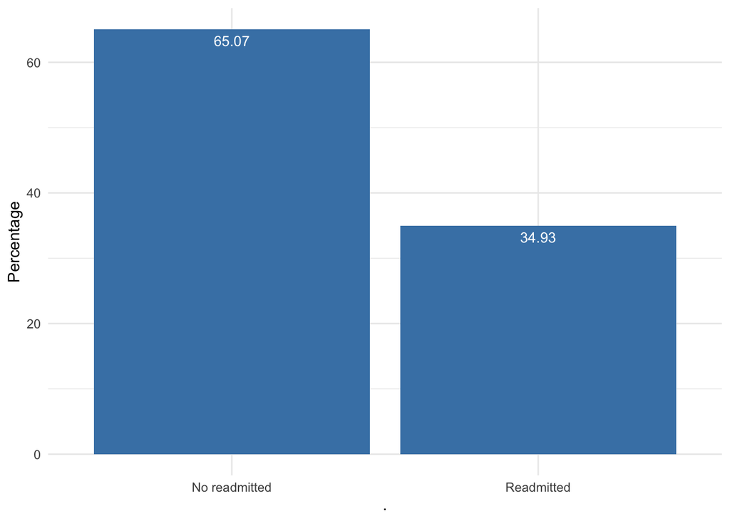

```r
tbl %>%
  dplyr::select(readmitted) %>%
  dplyr::mutate(readmitted = ifelse(readmitted == 1, 'Readmitted', 'No readmitted')) %>%
  table() %>%
  as.data.frame() %>%
  dplyr::mutate(Perc = round(Freq/sum(Freq) * 100, 2)) %>%
  ggplot(aes_string(x = '.', y = 'Perc')) +
  geom_bar(stat="identity", fill="steelblue")+
  theme_minimal() +
  geom_text(aes(label = Perc), vjust = 1.6, color = "white", size = 3.5) +
  ylab('Percentage')
```

EDA highlights:

- In average the number of days of hospitalization is around 4
- The number of laboratory procedures, general procedures, medications, outpatient, emergency, and inpatient numbers, are positive skewed
- The number of confirmed diagnoses range between 1 and 16 with a median of 8 diagnoses
- The number of visits to the hospital network is positive skewed which means the majority of patients visits just one time. And just a few proportion visits more than once
- 75% of the patients are more than 55 years old
- The response variable has a distribution of 65% (no readmission) vs 35% (readmission)

## 4. Correlation Analysis

The correlation analysis explore the association between all of different pairs of variables in the dataset. This step is very important to discard some highly correlated features before the classification analysis.

The correlation analysis was carried out using the dataset with transformed features (dummy variables instead of the original categorical data) using the Spearman non-parametric correlation. This correlation coefficient explores monotonic (increasing or decreasing) association but not necessarily linear.

```r
## --------------------------------------------------- ##
## Correlation Analysis
## --------------------------------------------------- ##

tbl_num_full <- vroom::vroom('./processed_data/diabetic_data_processed_2_complete.csv', delim = ',')
```

```
## Rows: 57,642
## Columns: 42
## dbl [42]: time_in_hospital, num_lab_procedures, num_procedures, num_medications, number_ou...
##
## Pass a specification to the `col_types` argument to quiet this message
```

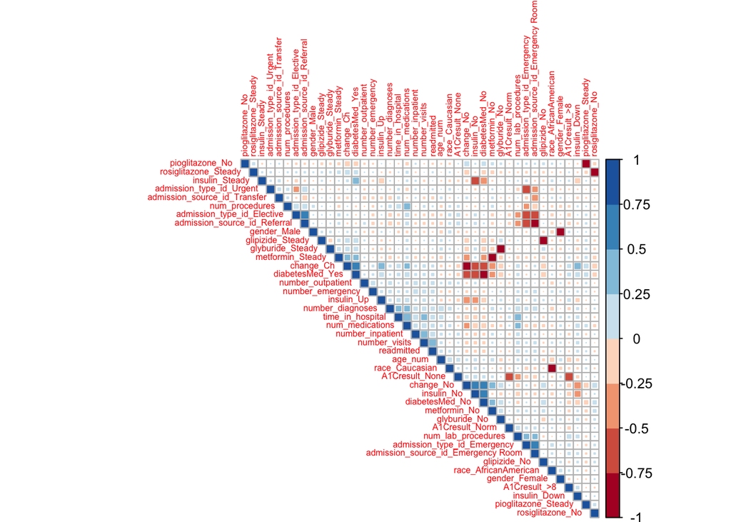

```r
# This function approximates the correlation calculation for
# mixed variables (numerical and categorical). The following
# cases are considered:
# - Both variables numeric: non-parametric Spearman correlation
# - One variable categorical, the other one numerical: ANOVA
# test getting the R2 and applying the square root
# - Both variables categorical: Cramer's V test to measure
# association between two nominal variables
# Taken from https://gist.github.com/talegari/b514dbbc651c25e2075d88f31d48057b
source('./scripts/cor2_modified.R')

m <- cor2(df = tbl_num_full)
corrplot::corrplot(m,
                   type   = "upper",
                   method = "square",
                   order  = "hclust",
                   col    = brewer.pal(n = 8, name = "RdBu"),
                   tl.cex   = .5)
```

## 5. Feature Selection

Before studying the factors that insides in the readmission condition, One important step is to identify which are the features that contributes the most to explain the response variable.

This process is done by the application of the [Boruta algorithm](https://www.jstatsoft.org/article/view/v036i11) which uses Random Forest models to quantify the importance of each predictor variable to explain the response variable. The result from this process are three category response per variable. The categories are: *Confirmed*, *Tentative*, or *Rejected*.

Despite it is not possible to apply this algorithm over the full dataset considering the machine resources a resample approach was applied. The approach followed consists in:

- Generate 20 random samples of 2000 patient observations
- Over each random sample run the Boruta algorithm
- Obtain the final decision per variable
- Using the 20 results create a frequency table getting the decision category with the maximum absolute frequency
- Select the features which have the levels: *Confirmed* and *Tentative*

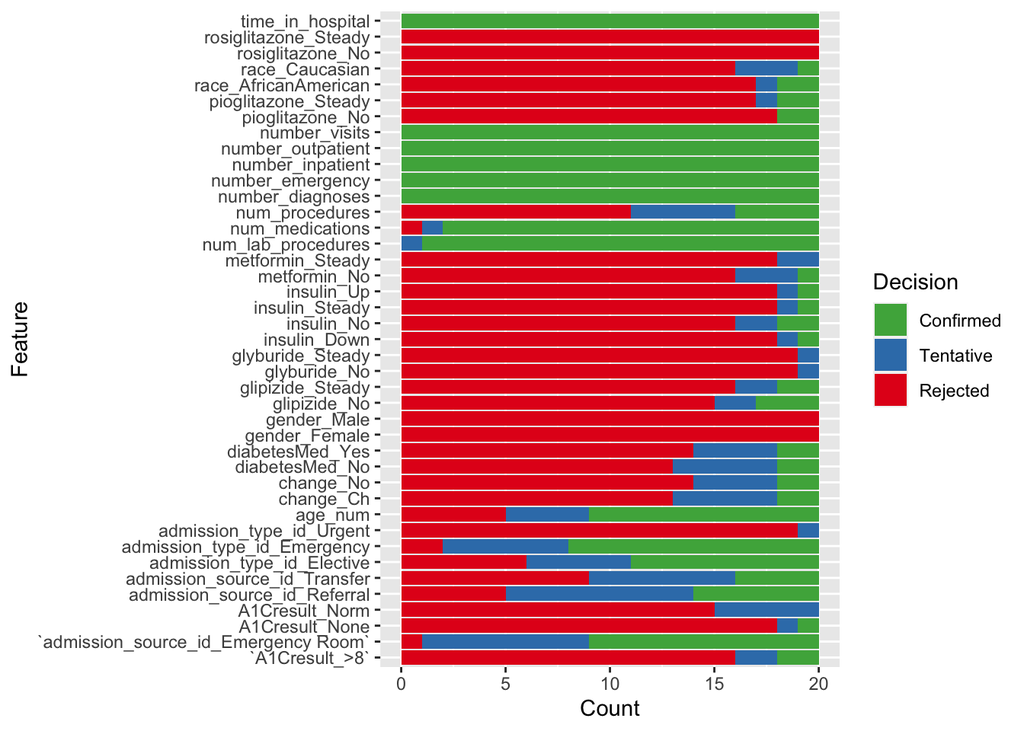

```r
## --------------------------------------------------- ##
## Feature selection
## --------------------------------------------------- ##

out_dir <- './results'
if(!dir.exists(out_dir)){dir.create(out_dir, recursive = T)}
if(!file.exists(paste0(out_dir,'/feature_selection_simulation.csv'))){

  # Generate a local cluster of processors
  future::plan(multiprocess, workers = future::availableCores()-1)
  # Define a seed to do the results replicable
  set.seed(1)
  # Generate 20 random seeds from a uniform distribution
  seeds <- round(runif(20) * 1000, 0)
  # Run Boruta algorithm of feature selection using 20
  # random subsets of 2000 patients information and
  # save final decision: features CONFIRMED, TENTATIVE,
  # and REJECTED
  selected_fts <- seeds %>%
    furrr::future_map(.f = function(seed){
      # Fix each seed
      set.seed(seed)
      # Obtain a random sample without replacement of 2000 observations
      smp <- sample(x = 1:nrow(tbl_num_full), size = 2000, replace = F)
      # Run Boruta algorithm of feature selection over this random sample
      fts <- Boruta::Boruta(formula = readmitted ~ ., data = tbl_num_full[smp,])
      # Get the final decision
      res <- fts$finalDecision
      return(res)
    })

  fts <- selected_fts %>% as.data.frame()
  fts$Feature <- rownames(fts)
  rownames(fts) <- 1:nrow(fts)
  colnames(fts)[1:20] <- paste0('Run_',1:20)

  write.csv(fts, paste0(out_dir,'/feature_selection_simulation.csv'), row.names = F)
} else {
  fts <- read.csv(paste0(out_dir,'/feature_selection_simulation.csv'))
}

fts %>%
  tidyr::pivot_longer(cols = Run_1:Run_20) %>%
  dplyr::group_by(Feature, value) %>%
  dplyr::summarise(Count = n()) %>%
  ggplot2::ggplot(aes(x = Feature, y = Count, fill = factor(value, levels = c('Confirmed','Tentative','Rejected')))) +
  ggplot2::scale_fill_brewer(palette = 'Set1', direction = -1) +
  ggplot2::geom_bar(stat = 'identity') +
  ggplot2::coord_flip() +
  ggplot2::labs(fill = 'Decision')
```

```r
fnl_fst <- fts %>%
  tidyr::pivot_longer(cols = Run_1:Run_20) %>%
  dplyr::group_by(Feature, value) %>%
  dplyr::summarise(Count = n()) %>%
  dplyr::ungroup() %>%
  dplyr::group_by(Feature) %>%
  dplyr::summarise(Decision = value[which.max(Count)]) %>%
  dplyr::filter(Decision %in% c('Confirmed','Tentative')) %>%
  dplyr::pull(Feature)
fnl_fst[1] <- gsub('\`','',fnl_fst[1])
cat('Selected features from Boruta algorithm\n')
```

```
## Selected features from Boruta algorithm
```

```r
print(fnl_fst)
```

```
##  [1] "admission_source_id_Emergency Room" "admission_source_id_Referral"
##  [3] "admission_type_id_Elective"         "admission_type_id_Emergency"
##  [5] "age_num"                            "num_lab_procedures"
##  [7] "num_medications"                    "number_diagnoses"
##  [9] "number_emergency"                   "number_inpatient"
## [11] "number_outpatient"                  "number_visits"
## [13] "time_in_hospital"
```

```r
tbl_num_full_sel <- tbl_num_full[,c(fnl_fst,'readmitted')]
```

Finally, 13 variables were selected and are going to be used to the classification analysis reducing the number of features and hence the model complexity.

## 6. Classification Analysis

The classification analysis was used to understand how the measured conditions affect the readmission scenario. The pipeline includes the following steps:

- Split the dataset in two partitions: training (70%) and testing (30%) data
- Over these partitions, adjust five models: a logistic regression, a artificial neural network with two hidden layers and 26 nodes each, a decision tree* model, a random forest model with 100 trees, and a gradient boosting trees* model
- Obtain the accuracy as a performance metric for all the models. This score allows to determine the percentage of correct classification either by readmission and not readmission conditions.
- Select the model with the best performance
- Calculate variable importance for all the features using the [moDel Agnostic Language for Exploration and eXplanation (DALEX)](https://github.com/ModelOriented/DALEX) methods
- Use the partial dependency plots as a way to understand the relation direction and to complement the variable importance
- Finally, obtain a decomposition of individual case-study predictions using [BreakDown](https://arxiv.org/abs/1804.01955) algorithm, to interpret how the best model is doing the predictions.

* These models were fitted with default set of hyper-parameters.

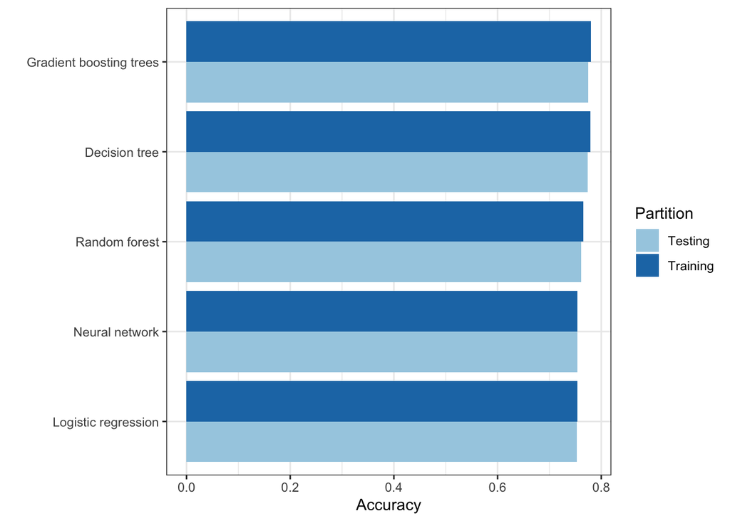

```r
## --------------------------------------------------- ##
## Classification analysis
## --------------------------------------------------- ##

if(!file.exists('./results/model_accuracies.csv')){

  # Spark connection
  if(!exists('sc')){
    sc <- sparklyr::spark_connect(master = 'local', version = '3.0.1')
  }
  tbl_num_full_sel_spk <- sparklyr::copy_to(sc, tbl_num_full_sel, overwrite = T)

  # Define partitions of the dataset: 70% for training, 30% for testing
  partitions <- tbl_num_full_sel_spk %>%
    sparklyr::sdf_partition(training = 0.7, test = 0.3, seed = 1099)

  # Fit a logistic regression model
  fit_log <- partitions$training %>% ml_logistic_regression(readmitted ~ .)
  # Evaluate one model manually
  # prd_log <- ml_predict(fit_log, partitions$test)
  # ml_binary_classification_evaluator(x = prd_log, label_col = 'readmitted', raw_prediction_col = 'prediction')

  # Fit a neural network
  fit_ann <- partitions$training %>% ml_multilayer_perceptron_classifier(readmitted ~ ., layers = c(13, 26, 26, 2))

  # Fit a decision tree model
  fit_dct <- partitions$training %>% ml_decision_tree(readmitted ~ ., type = 'classification')

  # Fit a random forest model
  fit_rdf <- partitions$training %>% ml_random_forest(readmitted ~ ., type = 'classification', num_trees = 100)

  # Fit a gradient boosting trees model
  fit_gbt <- partitions$training %>% ml_gradient_boosted_trees(readmitted ~ ., type = 'classification')

  metrics <- data.frame(Model = c('Logistic regression', 'Neural network','Decision tree', 'Random forest', 'Gradient boosting trees'),
                        Training = c(ml_evaluate(fit_log, partitions$training)$accuracy(),
                                     ml_evaluate(fit_ann, partitions$training)$Accuracy,
                                     ml_evaluate(fit_dct, partitions$training)$Accuracy,
                                     ml_evaluate(fit_rdf, partitions$training)$Accuracy,
                                     ml_evaluate(fit_gbt, partitions$training)$Accuracy),
                        Testing  = c(ml_evaluate(fit_log, partitions$test)$accuracy(),
                                     ml_evaluate(fit_ann, partitions$test)$Accuracy,
                                     ml_evaluate(fit_dct, partitions$test)$Accuracy,
                                     ml_evaluate(fit_rdf, partitions$test)$Accuracy,
                                     ml_evaluate(fit_gbt, partitions$test)$Accuracy))
  write.csv(metrics, './results/model_accuracies.csv', row.names = F)
} else {
  metrics <- read.csv('./results/model_accuracies.csv')
}

metrics %>%
  tidyr::pivot_longer(cols = 2:3, names_to = 'Partition', values_to = 'Accuracy') %>%
  ggplot2::ggplot(aes(x = reorder(Model, Accuracy), y = Accuracy, fill = Partition)) +
  ggplot2::geom_bar(stat = "identity", position = position_dodge()) +
  ggplot2::scale_fill_brewer(palette = "Paired") +
  ggplot2::coord_flip() +
  ggplot2::theme_bw() +
  ggplot2::xlab('')
```

```r
cat('Based on the accuracy metric the best model is the Gradient boosting trees\n')
```

```
## Based on the accuracy metric the best model is the Gradient boosting trees
```

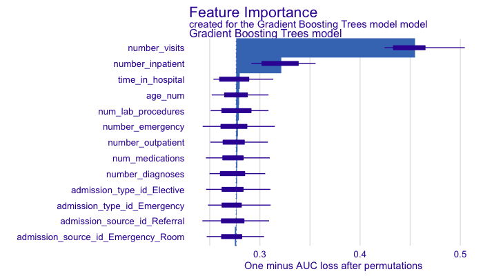

```r
if(FALSE){
  # Interpretation of the results
  test_set <- partitions$test %>% dplyr::collect()
  custom_predict <- function(model, new_data){

    new_data_spark <- copy_to(sc, new_data, name="spark_temp1b3c4e6", overwrite = T)
    spark_tbl_scored <- ml_predict(model, new_data_spark)
    res <- as.numeric(as.data.frame(spark_tbl_scored %>% select(prediction) %>% collect())$prediction)
    # dplyr::db_drop_table(con = sc, table = "spark_temp1b3c4e6")

    return(res)
  }

  # Explain
  xpl_spark_gbt <- DALEX::explain(model            = fit_gbt,
                                  data             = test_set %>% select(-readmitted),
                                  y                = test_set$readmitted,
                                  predict_function = custom_predict,
                                  label            = 'Gradient Boosting Trees model',
                                  type             = 'classification')

}

if(!file.exists('./results/gbt_variable_importance.png')){
  # Variable importance
  vim_spark_gbt <- DALEX::variable_importance(xpl_spark_gbt)
  plot(vim_spark_gbt)
} else {
  vimp <- './results/gbt_variable_importance.png'
  knitr::include_graphics(vimp)
}
```